# Reference label transfer from the fetal full reference (Cao et al.) for SCPCS000178

Maud PLASCHKA

2024-08-07

## Introduction

The aim is to perform label transfer as a step of the annotation of the Wilms tumor dataset for the sample `param$sample_id` =

```r
params$sample_id
```

```
## [1] "SCPCS000178"
```

The use of the right reference is crucial. It is recommended that the cell types in the reference is representative to the cell types to be annotated in the query.

Wilms tumors can contain up to three histologies that resemble fetal kidney: blastema, stroma, and epithelia [1-2]. Because of their histological similarity to fetal kidneys, Wilms tumors are thought to arise from developmental derangements in embryonic renal progenitors.

We thus decided to test and compare fetal (kidney) references that could be use in the analysis module. You can find below the two references that we plan to use

### Human fetal kidney atlas Stewart et al.

Stewart et al. created and a human fetal kidney atlas. We will use `Azimuth` to transfer label into the Wilms tumor samples. You can find more about the human kidney atlas here: https://www.kidneycellatlas.org/ [3]

### Azimuth Human fetal atlas Cao et al.

Azimuth also provide a human fetal atlas as a reference [4].

The data can be found on Zenodo: https://zenodo.org/records/4738021#.YJIW4C2ZNQI

The reference contain cells from 15 organs including kidney from fetal samples. Here we will use `Azimuth` to transfer labels from the reference.

In this notebook, we perform label transfer from the human fetal Azimuth reference from Cao et al.

### Packages

Load required packages in the following chunk, if needed. Do not install packages here; only load them with the `library()` function.

```r
library(Seurat)
library(SeuratData)
library(sctransform)
library(SCpubr)
library(tidyverse)
library(patchwork)
library(SingleCellExperiment)

set.seed(params$seed)
```

### Base directories

```r
# The base path for the OpenScPCA repository, found by its (hidden) .git directory
repository_base <- rprojroot::find_root(rprojroot::is_git_root)

# The path to this module
module_base <- file.path(repository_base, "analyses", "cell-type-wilms-tumor-06")
```

```r
# load functions for label transfer
source(
  file.path(
    module_base,
    "notebook_template",
    "utils",
    "label-transfer-functions.R"
  )
)
```

### Input files

#### Reference

Load the Azimuth reference which has been prepared for label transfer.

```r
path_to_ref <- file.path(
  module_base,
  "results",
  "references",
  "cao_formatted_ref.rds"
)
if (!file.exists(path_to_ref)) {
  stop("Reference file could not be found. Make sure `scripts/prepare-fetal-references.R` has been run first.")
}
ref <- readRDS(path_to_ref)

# Pull out information from the reference object we need for label transfer
reference <- ref$reference
refdata <- ref$refdata
dims <- ref$dims
annotation_levels <- ref$annotation_levels
```

#### Query

In this notebook, we test the label transfer from the azimuth fetal atlas (reference) to the Wilms tumor sample defined in `params$sample_id` from the Wilms tumor dataset `param$scpca_project_id`.

We work with the pre-processed `Seurat`object saved in the `results` directory.

```r
data_dir <- file.path(module_base, "results", params$sample_id)
```

### Output file

Reports will be saved in the `notebook/02-reference` directory. The pre-processed and annotated `Seurat` object per samples are saved in the `result` folder.

```r
output_dir <- file.path(module_base, "results", params$sample_id)
```

## Analysis

### Load the pre-process data (query)

```r
# open the processed rds object
srat <- readRDS(file.path(data_dir, paste0("01-Seurat_", params$sample_id, ".Rds")))
srat_assay <- "RNA"

# prepare the query for label transfer
# we don't want to overwrite the srat object since `prepare_query`
#  removes features that are not present in the reference
DefaultAssay(srat) <- srat_assay
query <- prepare_query(
  srat,
  rownames(reference),
  srat_assay,
  params$homologs_file
)
```

### Label transfer from fetal kidney reference using Azimuth

```r
options(future.globals.maxSize = 891289600000000)

# determine k.weight based CI
if (params$testing) {
  k.weight <- 10 # only for test datasets
} else {
  k.weight <- 50 # Azimuth default
}
query_labeled <- transfer_labels(
  query,
  reference,
  dims,
  refdata,
  query.assay = srat_assay,
  k.weight = k.weight
)
# We transfer the annotation to the pre-processed `Seurat` object as we don't want to keep changes done on the query by Azimuth
annotation_columns <- c(
  glue::glue("predicted.{annotation_levels}"),
  glue::glue("predicted.{annotation_levels}.score")
)
metadata_to_transfer <- query_labeled@meta.data[, annotation_columns]

srat <- AddMetaData(srat, metadata_to_transfer, col.name = paste0("fetal_full_", annotation_columns))

rm(query)
rm(query_labeled)
```

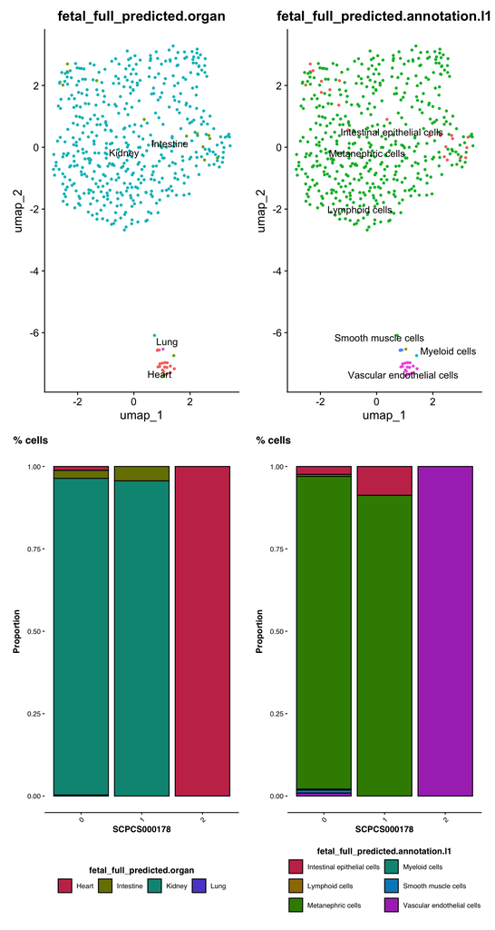

```r
d1 <- DimPlot(srat, reduction = "umap", dims = c(1, 2), group.by = "fetal_full_predicted.organ", label = TRUE, repel = TRUE) + NoLegend()
d2 <- DimPlot(srat, reduction = "umap", dims = c(1, 2), group.by = "fetal_full_predicted.annotation.l1", label = TRUE, repel = TRUE) + NoLegend()
d3 <- DimPlot(srat, reduction = "umap", dims = c(1, 2), group.by = "fetal_full_predicted.annotation.l2", label = TRUE, repel = TRUE) + NoLegend()

f1 <- SCpubr::do_BarPlot(
  sample = srat,
  group.by = "fetal_full_predicted.organ",
  split.by = "seurat_clusters",
  position = "fill",
  font.size = 10,
  legend.ncol = 4
) +
  ggtitle("% cells") +
  xlab(params$sample_id)

f2 <- SCpubr::do_BarPlot(
  sample = srat,
  group.by = "fetal_full_predicted.annotation.l1",
  split.by = "seurat_clusters",
  position = "fill",
  font.size = 10,
  legend.ncol = 2
) +
  ggtitle("% cells") +
  xlab(params$sample_id)

f3 <- SCpubr::do_BarPlot(
  sample = srat,
  group.by = "fetal_full_predicted.annotation.l2",
  split.by = "seurat_clusters",
  position = "fill",
  font.size = 10,
  legend.ncol = 2
) +
  ggtitle("% cells") +
  xlab(params$sample_id)

((d1 / f1) | (d2 / f2))
```

## Save the `Seurat`object

```r
saveRDS(object = srat, file = file.path(output_dir, paste0("02a-fetal_full_label-transfer_", params$sample_id, ".Rds")))
```

## References

- [1] https://www.ncbi.nlm.nih.gov/books/NBK373356/
- [2] https://www.ncbi.nlm.nih.gov/pmc/articles/PMC9915828/
- [3] https://www.science.org/doi/10.1126/science.aat5031
- [4] https://www.science.org/doi/10.1126/science.aba7721